# Tres caminos para clonar/descargar un repositorio de GitHub

Para replicar las clases del curso “Taller de R: Estadística y programación” (ver repositorio del curso en GitHub [aquí](https://github.com/taller-R)) o cualquier otro repositorio libre en GitHub, usted puede seguir cualquiera de estos tres caminos. Sin embargo, en cualquiera de los tres casos, es necesario que usted se registre y cree una cuenta en [GitHub](https://github.com/) previamente.

## Descargar el respositorio manualmente.

[figure not shown]

Al hacer esto usted obtiene un archivo de extención **.zip** que debe descomprimir. Desde este momento usted puede usar todos los archivos del repositorio. Para propositos de la clase, es importante que usted lea los archivos *README.html* y el otro archivo *.html* que está en la carpeta **help**.

## Usando la URL del repositorio.

Podemos descargar el repositorio usando la *URL* del archivo **.zip**. Para ello, primero vamos a ir a la consola de Rstudio y generamos un script y pegamos directorio de trabajo en el que deseamos descargar la carpeta.

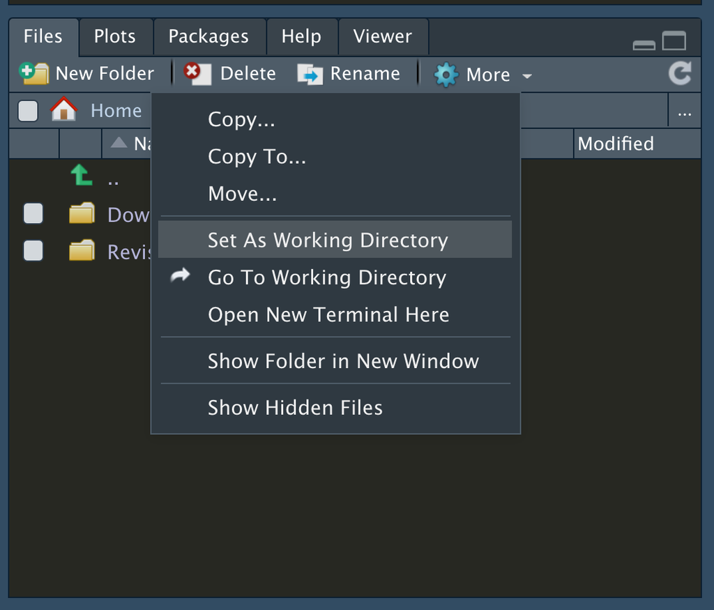

Y copiamos el código que se genera en la consola `setwd("~/Downloads")` y lo pegamos en el script.

```r
# By: Eduard Martinez
# Date: 16-08-2020

# Vamos a establecer el directorio de trabajo
#setwd("~/Downloads")
```

[figure not shown]

```r
# Descargar el repositorio
#download.file(url = "https://github.com/taller-R/Clase_1/archive/master.zip",
#              destfile = "clase_1.zip")
```

Ahora debemos tener en un nuestro directorio de trabajo, un archivo llamdo “clase_1.zip” en formato **.zip** son el contenido del repositorio.

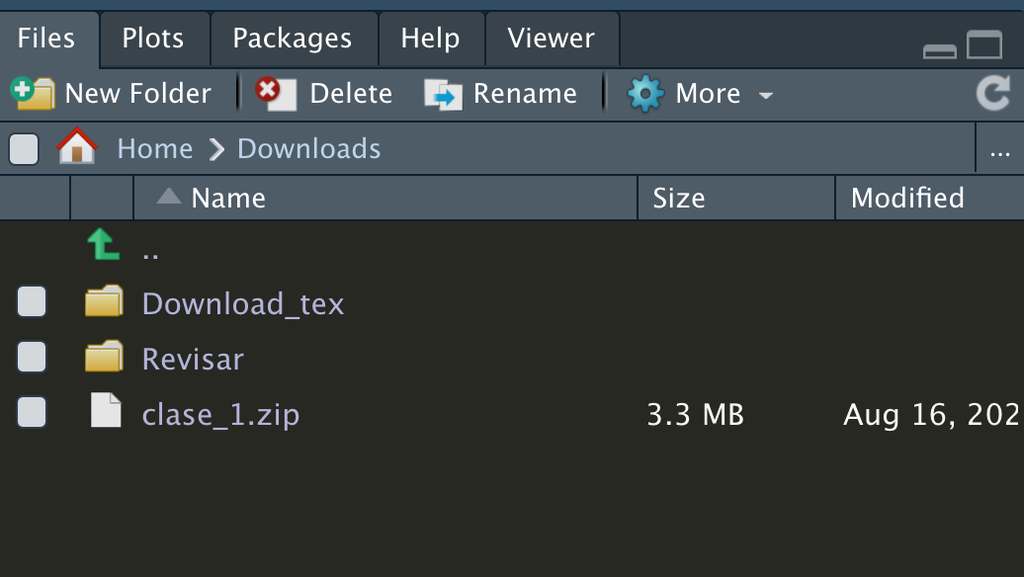

Ahora vamos a descomprimir este archivo, para ello vamos a usar la función `unzip` del paquete `utils`.

```r
# Descomprimir el archivo
#unzip(zipfile = "clase_1.zip")
```

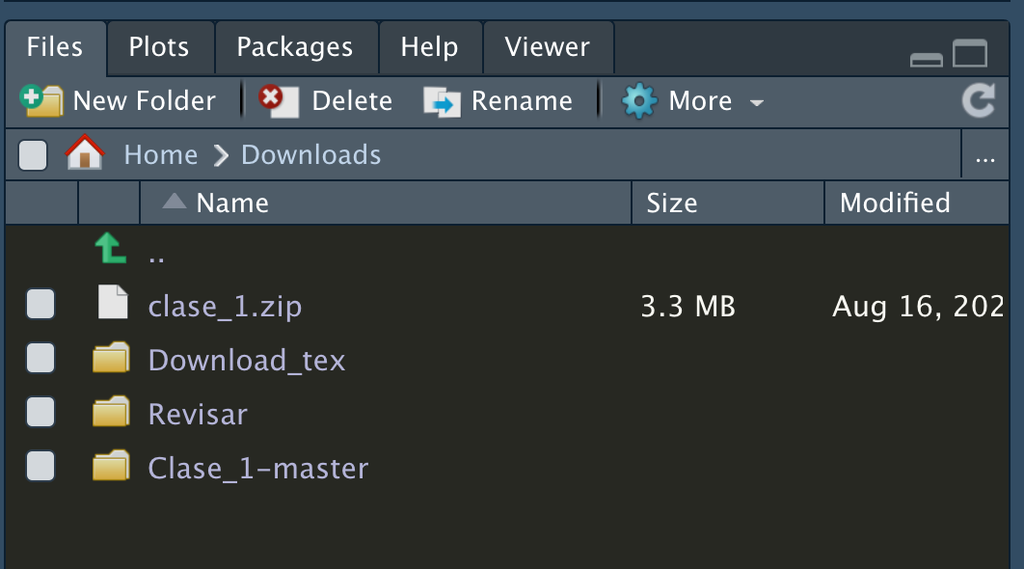

```r
# Cambiar el directorio de trabajo
#setwd("~/Downloads/clase_1-master")

# Inspeccionar archivos en el directorio
list.files()
```

```
##  [1] "clonar_github.html" "clonar_github.Rmd"  "github"
##  [4] "graphs"             "page_a.html"        "page_a.Rmd"
##  [7] "page_b.html"        "page_b.Rmd"         "page_c.html"
## [10] "page_c.Rmd"         "page_d.html"        "page_d.Rmd"
```

## Crear un proyecto de versión de control.

Otra forma de replicar un repositorio en GitHub, es crear un proyecto de versión de control en R. Para ello, primero tenemos que istalar [git](https://git-scm.com), un sistema de control de versiones. Primero tenemos que elegir el instalador que sea compatible con el sistema operativo de nuestro computador.

[figure not shown]

### 3.1.1 Instalación de Git en Windows.

Si usted tiene un Windows solo debe descargar el instalador de [git bash](https://git-scm.com/download/win) (Git for Windows Setup de 32-bit o 64-bit) e instalarlo.

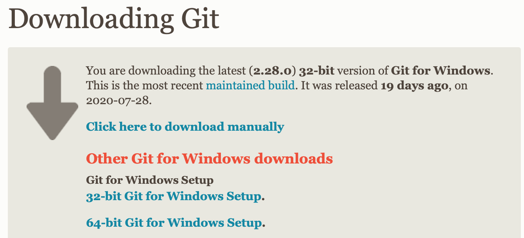

### 3.1.2 Instalación de Git en Mac.

Si usted tiene un Mac, primero debe ir a la terminal de su equipo (puede hacerlo desde Rstudio) e instalar [Homebrew](https://brew.sh/index_es). “*Homebrew* instala todo aquello que necesitas que Apple no instala de serie”. Para instalarlo, debes copiar este codígo `/bin/bash -c "$(curl -fsSL https://raw.githubusercontent.com/Homebrew/install/master/install.sh)"` y pegarlo en la terminal.

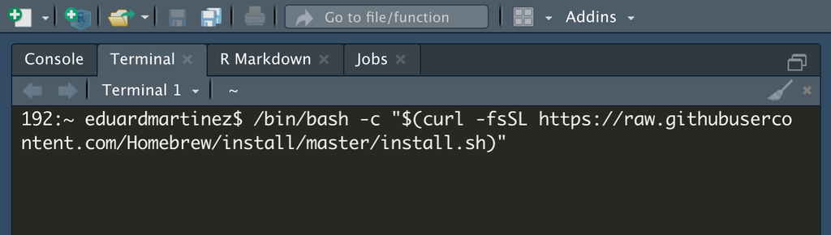

Ahora puede instalar Git copiando y pengando este comnado en la terminal `brew install git`.

[figure not shown]

### 3.2 Configuración inicial de Git.